# Question 2 - LDA Topic Modelling of News Articles

## Packages and parameters

```r
# install.packages(c("tidyverse","tidytext","topicmodels","textstem","wordcloud","RColorBrewer","reshape2","ldatuning"))
library(tidyverse)
library(tidytext)
library(topicmodels)
library(textstem)
library(wordcloud)
library(RColorBrewer)

N_TOPICS <- 5     # n: number of topics
K_WORDS  <- 10    # k: top words shown per topic
set.seed(1234)
```

## 2.1 Load the news files into a data frame and denoise

```r
zip_path <- "news.zip"                 # place news.zip next to this notebook
unzip(zip_path, exdir = "news_raw")

files <- list.files("news_raw", pattern = "\\.txt$", recursive = TRUE, full.names = TRUE)

news_df <- tibble(
  file_name = basename(files),
  content   = map_chr(files, ~ paste(readLines(.x, warn = FALSE, encoding = "UTF-8"), collapse = " "))
)

glimpse(news_df)
```

```
## Rows: 10
## Columns: 2
## $ file_name <chr> "news_1.txt", "news_10.txt", "news_2.txt", "news_3.txt", "ne…
## $ content   <chr> "Eskom former official, service provider appear in court Tue…
```

Denoising steps: strip HTML tags and URLs, lower-case, remove digits and punctuation, collapse whitespace, remove stop words and very short tokens, lemmatise.

```r
clean_text <- function(x) {
  x |>
    str_replace_all("<[^>]+>", " ") |>           # HTML
    str_replace_all("http\\S+|www\\.\\S+", " ") |> # URLs
    str_replace_all("\\S+@\\S+", " ") |>         # e-mails
    str_to_lower() |>
    str_replace_all("[^a-z\\s]", " ") |>         # punctuation, digits, symbols
    str_squish()
}

news_df <- news_df |> mutate(clean = clean_text(content))

extra_stop <- c("said","say","says","will","also","would","could","one","two","new","year","years","mr","mrs")

tokens <- news_df |>
  select(file_name, clean) |>
  unnest_tokens(word, clean) |>
  filter(!word %in% stop_words$word,
         !word %in% extra_stop,
         nchar(word) > 2) |>
  mutate(word = lemmatize_words(word))

# lemmatising can reintroduce stop words, so filter again
tokens <- tokens |> filter(!word %in% stop_words$word)

# remove very rare words (< 3 occurrences overall)
tokens <- tokens |> group_by(word) |> filter(n() >= 3) |> ungroup()

# preprocessed data frame (file_name, content)
news_clean <- tokens |>
  group_by(file_name) |>
  summarise(content = paste(word, collapse = " "), .groups = "drop")

head(news_clean)
```

```
## # A tibble: 6 × 2
##   file_name   content
##   <chr>       <chr>
## 1 news_1.txt  eskom official service provider court tuesday july eskom employee…
## 2 news_10.txt wet cold weather expect continue western cape monday july cold we…
## 3 news_2.txt  gauteng education commit implement mayibuye primary school remedi…
## 4 news_3.txt  labour minister tuesday july employment labour minister meth depa…
## 5 news_4.txt  police kidnap victim tuesday july action south african police ser…
## 6 news_5.txt  president ramaphosa condolence decease sandf tuesday july preside…
```

```r
cat("Documents:", nrow(news_clean), " Vocabulary:", n_distinct(tokens$word), "\n")
```

```
## Documents: 10  Vocabulary: 186
```

## 2.2 LDA

Document-term matrix and model:

```r
dtm <- tokens |>
  count(file_name, word) |>
  cast_dtm(file_name, word, n)

lda_model <- topicmodels::LDA(dtm, k = N_TOPICS, method = "Gibbs",
                 control = list(seed = 1234, burnin = 500, iter = 2000))
class(lda_model)
```

```
## [1] "LDA_Gibbs"
## attr(,"package")
## [1] "topicmodels"
```

```r
# posterior distributions (topic-word = beta, document-topic = gamma)
post <- topicmodels::posterior(lda_model)
```

Top k words per topic (beta = probability of the word given the topic, i.e. the word distribution):

```r
topic_words <- as_tibble(t(post$terms), rownames = "term") |>
  pivot_longer(-term, names_to = "topic", values_to = "beta") |>
  mutate(topic = as.integer(topic))

top_terms <- topic_words |>
  group_by(topic) |>
  slice_max(beta, n = K_WORDS, with_ties = FALSE) |>
  ungroup() |>
  arrange(topic, desc(beta))

top_terms
```

```
## # A tibble: 50 × 3
##    term           topic   beta
##    <chr>          <int>  <dbl>
##  1 government         1 0.120
##  2 coalition          1 0.0758
##  3 administration     1 0.0536
##  4 power              1 0.0359
##  5 role               1 0.0359
##  6 include            1 0.0270
##  7 governance         1 0.0270
##  8 policy             1 0.0270
##  9 relationship       1 0.0270
## 10 public             1 0.0226
## # ℹ 40 more rows
```

```r
# compact list view
top_terms |>
  group_by(topic) |>
  summarise(top_words = paste(term, collapse = ", "))
```

```
## # A tibble: 5 × 2
##   topic top_words
##   <int> <chr>
## 1     1 government, coalition, administration, power, role, include, governance…
## 2     2 public, south, africa, psc, country, gxoyiya, management, official, ser…
## 3     3 police, cape, cold, expect, gov, weather, west, western, african, sandf
## 4     4 department, report, priority, unemployment, meth, ensure, tuesday, scho…
## 5     5 service, invoice, national, day, pay, eskom, department, monday, paymen…
```

Word distribution reporting: how concentrated each topic is, and how topics spread over documents.

```r
# share of each topic's probability mass held by its top k words
topic_words |>
  group_by(topic) |>
  arrange(desc(beta), .by_group = TRUE) |>
  summarise(top_k_mass = sum(head(beta, K_WORDS)), vocab = n())
```

```
## # A tibble: 5 × 3
##   topic top_k_mass vocab
##   <int>      <dbl> <int>
## 1     1      0.452   186
## 2     2      0.486   186
## 3     3      0.324   186
## 4     4      0.362   186
## 5     5      0.521   186
```

```r
# document-topic distribution (gamma) and dominant topic per document
doc_topics <- as_tibble(post$topics, rownames = "document") |>
  pivot_longer(-document, names_to = "topic", values_to = "gamma") |>
  mutate(topic = as.integer(topic))

dominant <- doc_topics |>
  group_by(document) |>
  slice_max(gamma, n = 1, with_ties = FALSE) |>
  ungroup()

count(dominant, topic, name = "documents")
```

```
## # A tibble: 5 × 2
##   topic documents
##   <int>     <int>
## 1     1         1
## 2     2         2
## 3     3         3
## 4     4         2
## 5     5         2
```

(Optional) choosing n with coherence-style metrics:

```r
library(ldatuning)
res <- FindTopicsNumber(dtm, topics = seq(2, 12, 2),
        metrics = c("Griffiths2004","CaoJuan2009","Arun2010","Deveaud2014"),
        method = "Gibbs", control = list(seed = 1234), mc.cores = 2L)
FindTopicsNumber_plot(res)
```

[output not shown]

## 2.3 Visualisation

**Method 1 - faceted bar chart of top words per topic**

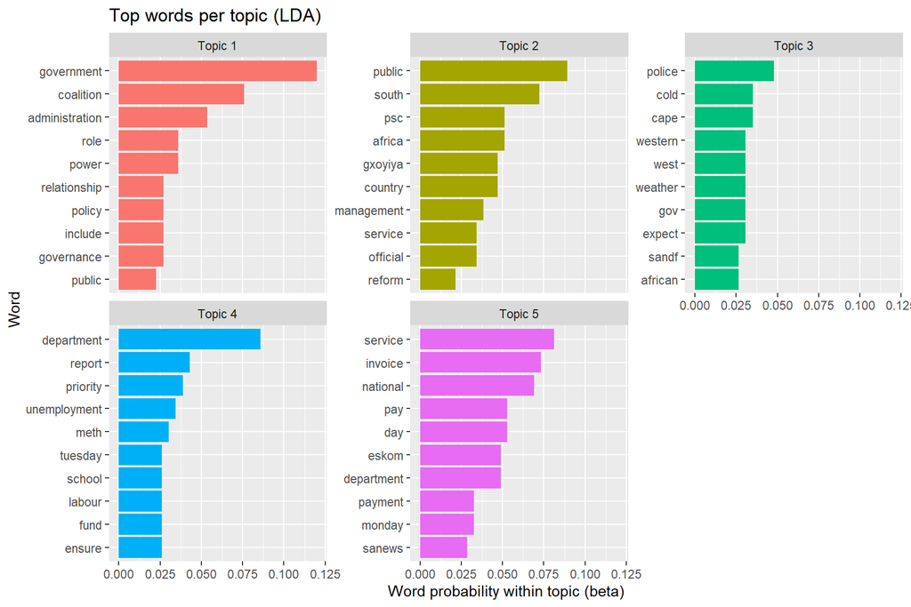

```r
top_terms |>
  mutate(term = reorder_within(term, beta, topic)) |>
  ggplot(aes(beta, term, fill = factor(topic))) +
  geom_col(show.legend = FALSE) +
  facet_wrap(~ paste("Topic", topic), scales = "free_y") +
  scale_y_reordered() +
  labs(title = "Top words per topic (LDA)",
       x = "Word probability within topic (beta)", y = "Word")
```

**Method 2 - word clouds per topic**

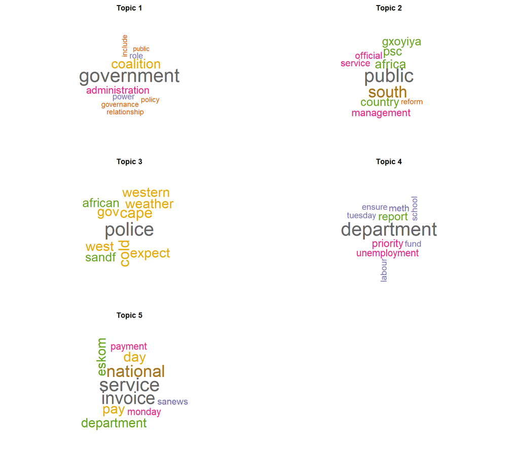

```r
par(mfrow = c(ceiling(N_TOPICS / 2), 2), mar = c(0, 0, 2, 0))
for (t in seq_len(N_TOPICS)) {
  d <- filter(top_terms, topic == t)
  wordcloud(d$term, d$beta, scale = c(3, 0.6), min.freq = 0,
            colors = brewer.pal(8, "Dark2"), random.order = FALSE)
  title(paste("Topic", t))
}
par(mfrow = c(1, 1))
```

**Method 3 (bonus) - document-topic heatmap**

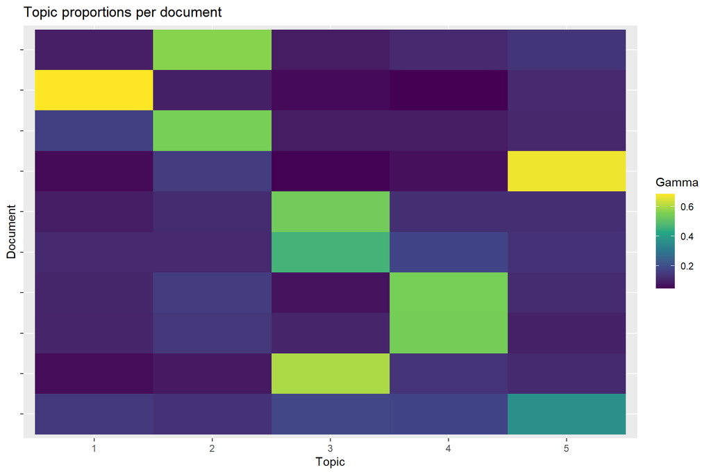

```r
ggplot(doc_topics, aes(factor(topic), document, fill = gamma)) +
  geom_tile() +
  scale_fill_viridis_c() +
  labs(title = "Topic proportions per document", x = "Topic", y = "Document", fill = "Gamma") +
  theme(axis.text.y = element_blank())
```

## Interpretation

- **Topic 1 (government and coalition politics):** dominated by *government*, *coalition*, *administration*, *power* and *governance*, i.e. coverage of how government and coalition arrangements work.
- **Topic 2 (public service management and reform):** *public*, *PSC*, *management*, *service*, *official* and *reform* suggest articles about the Public Service Commission and public-sector reform. “South” and “Africa” appear because the phrase South Africa is frequent, and *gxoyiya* is a name.
- **Topic 3 (police and cold weather):** a mixed topic combining *police* and *SANDF* with *cold*, *weather* and *Western Cape*. It has the lowest concentration (its top 10 words hold 32.4% of its probability) and dominates the most documents (3).
- **Topic 4 (labour, unemployment and education):** *department*, *unemployment*, *labour*, *school*, *fund* and *priority* point to employment and labour department announcements.
- **Topic 5 (government payments and Eskom):** *invoice*, *pay*, *payment*, *service* and *eskom* suggest articles about paying invoices and service providers; it is the most concentrated topic (top 10 words hold 52.1%).
- **Overall:** with only ten articles each topic dominates one to three documents, so the topics are broadly interpretable but not very stable. Day and month words (*tuesday*, *monday*, *july*) and *gov* are noise that could be added to the stop-word list, and a larger corpus would give more reliable topics.